# Analysis of fragmented river system

2026-03-04

## What we will cover in this presentation

- A general overview of connectivity indices for river networks
- Catchment Connectivity Index (\(CCI\)) and Reach Connectivity Index (\(RCI\))
- We will play around with parameters of the indices to see how they change
- Barriers prioritization with the \(dCCI\) index

## Connectivity/fragmentation indices

We define the Catchment Connectivity Index \(CCI\) as the weighted sum of all dispersal probabilities between river segments (reaches) in a catchment.

\[CCI = \sum_{i=1}^{n}\sum_{j=1}^{n}{ I_{ij}\frac{w_{i}w_{j}}{W^2}}\] where:

- \(I_{ij}\) is the dispersal probability between river reaches \(i\) and \(j\);
- \(w_i\) and \(w_j\) are the weights of the river reaches (e.g. their length, or their volume, or available habitat);
- \(W\) is the total weight of the river network (e.g. total length, or total volume, or available habitat).

## Connectivity/fragmentation indices

The term \(I_{ij}\) is the dispersal probability between river reaches \(i\) and \(j\). We factorize it to express the effect of barriers and dispersal:

\[I_{ij} = B_{ij}c_{ij}\] where:

- \(c_{ij}\) represents the effect of barriers when moving/dispersing from \(i\) to \(j\);
- \(B_{ij}\) represents the effect of distance when moving from \(i\) to \(j\).

## Connectivity/fragmentation indices

The term \(c_{ij}\) is the effect of barriers when moving/dispersing from \(i\) to \(j\). We express it as:

\[c_{ij} = \prod_{m = 1}^{k}{p_{m}^{eq}}\] where:

- \(p_{m}^{eq}\) is the probability of crossing barrier \(m\) on the path between \(i\) and \(j\);
- \(k\) is the number of barriers on the path between \(i\) and \(j\).

## Connectivity/fragmentation indices

The term \(p_{m}^{eq}\) is a metric that considers the passability of barrier \(m\). We consider both cases when the dispersal is symmetric and when it is asymmetric.

For symmetric dispersal, we express \(p_{m}^{eq}\) as the product of upstream and downstream passabilities (that are measured values, e.g. from telemetry studies:

\[p_{m}^{eq} = p_{m}^{u}p_{m}^{d}\] If the directionality is important, we express \(p_{m}^{eq}\) as the passability in the direction of interest:

\[p_{m}^{eq} = \begin{cases} p_{m}^{u} & \text{if m is crossed when moving upstream in the i to j path}\\ p_{m}^{d} & \text{if m is crossed when moving downstream in the i to j path } \end{cases} \]

## Connectivity/fragmentation indices

The term \(B_{ij}\) considers the dispersal/movement of organisms across the river network. We can formulate the dispersal kernel as a function of the distance between river reaches \(i\) and \(j\):

\[ B_{ij} = PD^{d_{ij}} \]

where:

- \(PD\) is the probability of dispersal per unit of distance (e.g. per 10s of km)
- \(d_{ij}\) is the distance between river reaches \(i\) and \(j\) (e.g. in 10s km)

## Connectivity/fragmentation indices

The term \(B_{ij}\) considers the dispersal/movement of organisms across the river network. Asymmeric dispersal can also be accounted for:

\[ B_{ij} = PD_{u}^{d_{ij}^{u}} PD_{d}^{d_{ij}^{d}} \]

where:

- \(PD_{u}\) and \(PD_{d}\) are the upstream and downlstream probabilities of dispersal per unit of distance (e.g. per 10s of km)
- \(d_{ij}^{u}\) and \(d_{ij}^{d}\) are the upstream/downstream travelled distances between river reaches \(i\) and \(j\) (e.g. in 10s km)

## Connectivity/fragmentation indices

An alternative formulation for \(B_{ij}\) can be done with a step function:

\[B_{ij} = \begin{cases} 1 & \text{when } d_{ij} < TR\\ 0 & \text{otherwise} \end{cases} \]

\[B_{ij} = \begin{cases} 1 & \text{when } d_{ij}^{u} < TR_{u} \text{ and } d_{ij}^{d} < TR_{d} \\ 0 & \text{otherwise} \end{cases} \]

where:

- \(TR\), \(TR_{u}\), \(TR_{d}\) are the threshold distances

Note that other dispersal kernels can be used (e.g. leptokurtic dispersal is well parametrized for many species and implemented in `riverconn`).

## Connectivity/fragmentation indices

We define the Reach Connectivity Index \(RCI_{i}\) as the weighted sum of all dispersal probabilities entering or exiting reach \(i\).

\[RCI = \sum_{j=1}^{n}{ I_{ij}\frac{w_{j}}{W}}\] The index can be calculated considering:

- only ‘inwards’ connections
- only ‘outwards’ connections

Note that the Dendritic Connectivity Index for diadromous \(DCId\) fish can be calculated as \(RCI\) with the outlet as focal reach.

## Connectivity/fragmentation indices

Barriers are prioritized using a leave-one-out approach. The importance of barrier \(m\) is calculated as the difference between the connectivity of the catchment with and without barrier \(m\):

\[dCCI_{m} = \frac{CCI_{0} - CCI_{-m}}{CCI_{0}} 100\] where:

- \(CCI_{0}\) is the connectivity of the catchment with all barriers;
- \(CCI_{-m}\) is the connectivity of the catchment without barrier \(m\)

## Which packages we will use

- `igraph` for graph manipulation: useful for building/editing/managing graphs;
- `riverconn` for calculating connectivity indices: the package we will use to calculate connectivity indices and prioritize barriers;
- `sf` and `terra` for vector and raster data manipulation;
- `dplyr` for data manipulation: helps building pipelines for easy-to-read data manipulation (loaded with the `tidyverse`);
- `ggplot2` for data visualization: a bit painful, but easily integrates `sf` and `terra` objects for plotting (loaded with the `tidyverse`).
- `dodgr` is a very important dependency in `riverconn` as it heavily speeds up distance-based calculation in graphs

## Which packages we will use

```r
library(tidyverse)
library(sf)
library(terra)
library(tidyterra)
library(viridis)
library(igraph)
library(riverconn)
```

## Data preprocessing

## Data preprocessing

We keep using the Ebro as a case study. we load the `igraph` object and the river shapefile we created in the previous lecture. We also identify the outlet.

```r
river_graph <- read_rds('data/river_graph/river_graph.rds')

river_net_simplified <- st_read("data/river_graph/river_net_simplified.shp",
                                quiet = TRUE) %>%
  dplyr::mutate(name = as.character(NodeID))

dams_shp <- st_read("data/dams_ebro/network_links.shp", quiet = TRUE) %>%
  dplyr::mutate(id_barrier = as.character(id_barrier)) %>%
  dplyr::filter(type =="dam")

outlet <- river_net_simplified$NodeID[river_net_simplified$DIST_DN_KM == 0 ]
```

## Data preprocessings

We examine the river graph we generated in the previous lecture.

```r
river_graph
```

```
## IGRAPH be8e943 DN-- 646 645 --
## + attr: name (v/n), length (v/n), HYRIV_ID (v/n), NEXT_DOWN (v/n),
## | MAIN_RIV (v/n), LENGTH_KM (v/n), DIST_DN_KM (v/n), DIST_UP_KM (v/n),
## | CATCH_SKM (v/n), UPLAND_SKM (v/n), ENDORHEIC (v/n), DIS_AV_CMS (v/n),
## | ORD_STRA (v/n), ORD_CLAS (v/n), ORD_FLOW (v/n), HYBAS_L12 (v/n),
## | elevation (v/n), type (e/c), id_links (e/n), id_barrier (e/c), pass_u
## | (e/n), pass_d (e/n)
## + edges from be8e943 (vertex names):
##  [1] 515->516 520->516 519->520 496->520 276->160 153->160 160->164 162->161
##  [9] 161->164 642->640 646->640 641->643 645->643 638->635 640->635 636->629
## [17] 644->629 632->631 639->631 629->628 631->630 630->628 628->627 627->624
## + ... omitted several edges
```

## Data preprocessings

Some attributes need to be adjusted.

```r
V(river_graph)$name <- as.character(V(river_graph)$name)
river_graph <- delete_vertex_attr(river_graph, "LENGTH_KM")
V(river_graph)$length = V(river_graph)$length/10000
```

## Data preprocessing

We define two functions to to assign a habitat suitability index (HSI) to each node of the graph.

- `suit_fun_high()`: habitat suitability for high-altitude organisms
- `suit_fun_low()`: habitat suitability for low-altitude organisms

```r
suit_fun_high <- function(x){dnorm(x, mean = 1500, sd = 500)*410*sqrt(3*pi)}
suit_fun_low <- function(x){exp(- 0.001*x)}

V(river_graph)$HSI_low <- suit_fun_low(V(river_graph)$elevation)
V(river_graph)$HSI_high <- suit_fun_high(V(river_graph)$elevation)
```

## Data preprocessing

A quick check on how the habitat suitability indices look like.

```r
plot <- 1:10:2500 %>%
  data.frame("Elevation" = .,
             "Low" = suit_fun_low(.),
             "High" = suit_fun_high(.)) %>%
  pivot_longer(c("Low", "High"),
               names_to = "Type", values_to = "HSI") %>%
  ggplot() +
  geom_line(aes(x = Elevation, y = HSI, color = Type))+
  theme_bw() + xlab("Elevation (m)") + ylab("Habitat Suitability Index (HSI)")
```

## Data preprocessing

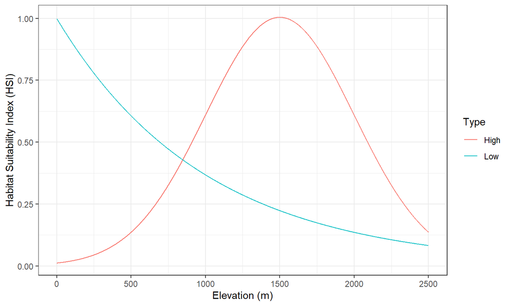

## CCI with `riverconn`

## CCI with `riverconn`

We calculate the Carchment Connectivity Index and then play around with the function parameters.

- We set `B_ij_flag = FALSE` because we do not have a dispersal kernel in this example.
- We set `index_type = "full"` because we are interested in calculating the \(CCI\).
- We set the weight to the field “length”.

```r
g <- river_graph
index_calculation(graph = g,
                  weight = "length",
                  B_ij_flag = FALSE,
                  index_type = "full")$index
```

```
## [1] 0.09043146
```

## CCI with `riverconn`

We calculate the same index, but using asymmetric dispersal.

- The index is higher because pass_u = 0.1 and pass_d = 0.8, while for the product is always used.
- Note that some arguments are omitted because the default values are used (see documentation).

```r
g <- river_graph
index_calculation(g, dir_fragmentation_type = "asymmetric", B_ij_flag = FALSE )$index
```

```
## [1] 0.2510495
```

## CCI with `riverconn`

We edit the passabilities.

```r
g <- river_graph
E(g)$pass_u <- E(g)$pass_d  <- ifelse(!is.na(E(g)$id_barrier),0.5,NA)
index_calculation(g, B_ij_flag = FALSE)$index
```

```
## [1] 0.1260329
```

```r
E(g)$pass_u <- E(g)$pass_d  <- ifelse(!is.na(E(g)$id_barrier),0,NA)
index_calculation(g, B_ij_flag = FALSE)$index
```

```
## [1] 0.07812939
```

## CCI with `riverconn`

We check the effect of the passability on the asymmetric indices.

```r
g <- river_graph
E(g)$pass_u <- ifelse(!is.na(E(g)$id_barrier),0.5,NA)
index_calculation(g, dir_fragmentation_type = "asymmetric",  B_ij_flag = FALSE)$index
```

```
## [1] 0.3417609
```

```r
E(g)$pass_u <- ifelse(!is.na(E(g)$id_barrier),0,NA)
index_calculation(g, dir_fragmentation_type = "asymmetric",  B_ij_flag = FALSE)$index
```

```
## [1] 0.2379491
```

## CCI with `riverconn`

We include the dispersal limitation with an exponentially decaying dispersal kernel

- We set the \(PD\) parameter to 0.8.
- We set the \(PD\) parameter to 0.3.

```r
g <- river_graph
index_calculation(g, disp_type = "exponential", param = 0.8)$index
```

```
## [1] 0.01371438
```

```r
index_calculation(g, disp_type = "exponential", param = 0.3)$index
```

```
## [1] 0.003304613
```

## CCI with `riverconn`

```r
g <- river_graph
index_calculation(g, disp_type = "exponential", dir_distance_type = "asymmetric",
                  param_u = 0.8, param_d = 0.5)$index
```

```
## [1] 0.007458711
```

```r
index_calculation(g, disp_type = "exponential", dir_distance_type = "asymmetric",
                  param_u = 0.8, param_d = 0.2)$index
```

```
## [1] 0.005747414
```

## CCI with `riverconn`

We include use the habitat suitability index as weight.

- We use the HSI for high altitude organisms.
- We use the HSI for low altitude organisms.

```r
g <- river_graph
index_calculation(g, weight = "HSI_high", param = 0.8)$index
```

```
## [1] 0.01373134
```

```r
index_calculation(g, weight = "HSI_low", param = 0.8)$index
```

```
## [1] 0.02054552
```

## RCI with `riverconn`

## RCI with `riverconn`

We calculate the REACH Connectivity Index and then play around with the function parameters.

- We set `B_ij_flag = FALSE` because we do not have a dispersal kernel in this example.
- We set `index_type = "reach"` because we are interested in calculating the \(RCI\).
- We set `index_mode = "to"`, as we consider all the connections exiting the reach of interest and going TO the network (a bit counter-intuitive…).

```r
g <- river_graph
index <- index_calculation(graph = g,
                           index_type = "reach",
                           index_mode = "to",
                           weight = "length",
                           B_ij_flag = FALSE)
```

## RCI with `riverconn`

The output of the function is a data.frame with the index value for each reach. We filter the output to show the index value for the outlet.

```r
head(index)
```

```
##   name       num      den       index
## 1    1 21.608798 813.1463 0.026574305
## 2    2 19.473934 813.1463 0.023948869
## 3    3 19.473934 813.1463 0.023948869
## 4    4  1.840274 813.1463 0.002263152
## 5    5 21.608798 813.1463 0.026574305
## 6    6 21.608798 813.1463 0.026574305
```

```r
index %>% dplyr::filter(name == outlet) %>% pull(index)
```

```
## [1] 0.04734412
```

## RCI with `riverconn`

We calculate the same index with asymmetric dispersal.

- The index is higher with pass_u = 0.5 and lower with pass_u = 0.1

```r
E(g)$pass_u <- ifelse(!is.na(E(g)$id_barrier),0.5,NA)
index_calculation(g, dir_fragmentation_type ="asymmetric",
                  index_type = "reach", index_mode = "to", B_ij_flag = FALSE) %>%
  dplyr::filter(name == outlet) %>% pull(index)
```

```
## [1] 0.1851834
```

```r
E(g)$pass_u <- ifelse(!is.na(E(g)$id_barrier),0.1,NA)
index_calculation(g,  dir_fragmentation_type ="asymmetric",
                  index_type = "reach", index_mode = "to", B_ij_flag = FALSE) %>%
  dplyr::filter(name == outlet) %>% pull(index)
```

```
## [1] 0.05122476
```

## RCI with `riverconn`

We edit the downstream passability.

- no change: all dispersal routes are moving upstream.

```r
E(g)$pass_d <- ifelse(!is.na(E(g)$id_barrier),0.5,NA)
index_calculation(g, dir_fragmentation_type ="asymmetric",
                  index_type = "reach", index_mode = "to", B_ij_flag = FALSE) %>%
  dplyr::filter(name == outlet) %>% pull(index)
```

```
## [1] 0.05122476
```

```r
E(g)$pass_d <- ifelse(!is.na(E(g)$id_barrier),0.1,NA)
index_calculation(g,  dir_fragmentation_type ="asymmetric",
                  index_type = "reach", index_mode = "to", B_ij_flag = FALSE) %>%
  dplyr::filter(name == outlet) %>% pull(index)
```

```
## [1] 0.05122476
```

## RCI with `riverconn`

We include use the habitat suitability index as weight.

- We use the HSI for high altitude organisms.
- We use the HSI for low altitude organisms.

```r
g <- river_graph
index_calculation(g, weight = "HSI_high", param = 0.8,
                  index_type = "reach", index_mode = "to") %>%
  dplyr::filter(name == outlet) %>% pull(index)
```

```
## [1] 0.001083473
```

```r
index_calculation(g, weight = "HSI_low", param = 0.8,
                  index_type = "reach", index_mode = "to",) %>%
  dplyr::filter(name == outlet) %>% pull(index)
```

```
## [1] 0.01773094
```

## Spatial patterns of RCI

## Spatial patterns of RCI

Now we analyze the spatial patterns of RCI. The index can easily be plotted together with the river shapefile. We calculate and plot the RCI with pass_u = pass_d = 0.5 and no dispersal limitation.

```r
index_list <- list()

E(g)$pass_u <- E(g)$pass_d  <- ifelse(!is.na(E(g)$id_barrier),0.5,NA)
index <- index_list[[1]]  <- index_calculation(
    g, dir_fragmentation_type ="symmetric",
    index_type = "reach", index_mode = "to", B_ij_flag = FALSE) %>%
  dplyr::mutate("def" = "no disp, pass = 0.5")

plot <- river_net_simplified %>%
  left_join(index, by = "name") %>%
  ggplot() +
  geom_sf(aes(color = index), size = 1) +
  scale_color_viridis() + theme_bw() +
  labs(color = "RCI")
```

## Spatial patterns of RCI

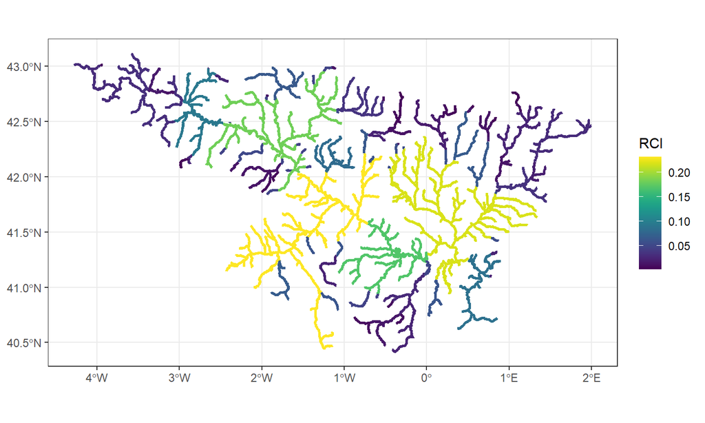

## Spatial patterns of RCI

We calculate and plot the RCI with pass_u = 0.1, pass_d = 0.8 and no dispersal limitation.

```r
g <- river_graph
index <- index_list[[2]]  <- index_calculation(
    g, dir_fragmentation_type ="asymmetric",
    index_type = "reach", index_mode = "to", B_ij_flag = FALSE) %>%
  dplyr::mutate("def" = "no disp, pass_u=0.1, pass_d=0.9")

plot <- river_net_simplified %>%
  left_join(index, by = "name") %>%
  ggplot() +
  geom_sf(aes(color = index), size = 1) +
  scale_color_viridis() + theme_bw() +
  labs(color = "RCI")
```

## Spatial patterns of RCI

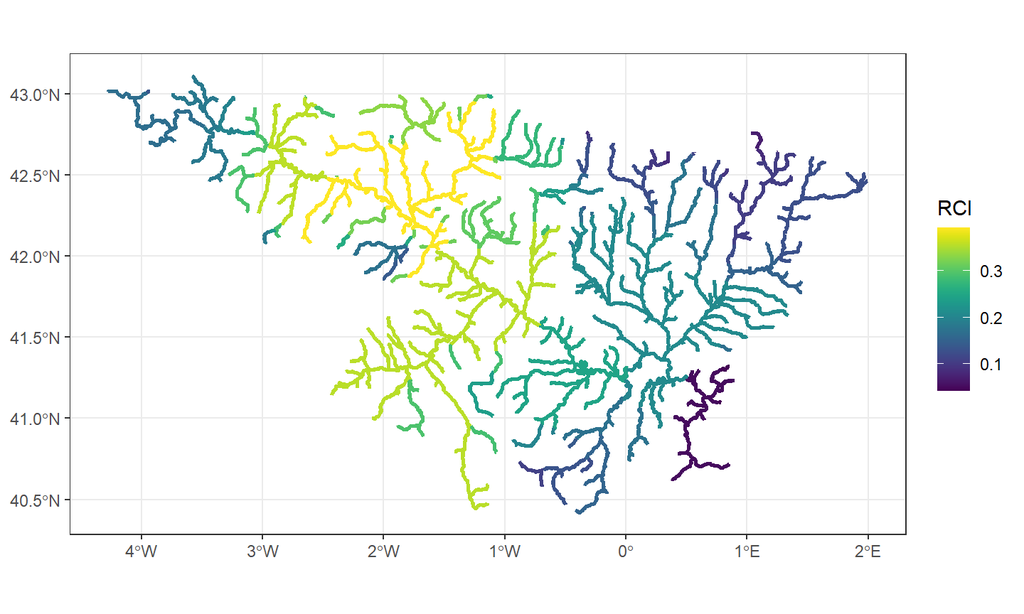

## Spatial patterns of RCI

We calculate and plot the RCI with pass_u = 0.1, pass_d = 0.8 and symmetric dispersal limitation (PD = 0.5).

```r
index <- index_list[[3]]  <- index_calculation(
    g, dir_fragmentation_type ="asymmetric",
    index_type = "reach", index_mode = "to", param = 0.5) %>%
  dplyr::mutate("def" = "PD=0.5, pass_u=0.1, pass_d=0.9")

plot <- river_net_simplified %>%
  left_join(index, by = "name") %>%
  ggplot() +
  geom_sf(aes(color = index), size = 1) +
  scale_color_viridis() + theme_bw() +
  labs(color = "RCI")
```

## Spatial patterns of RCI

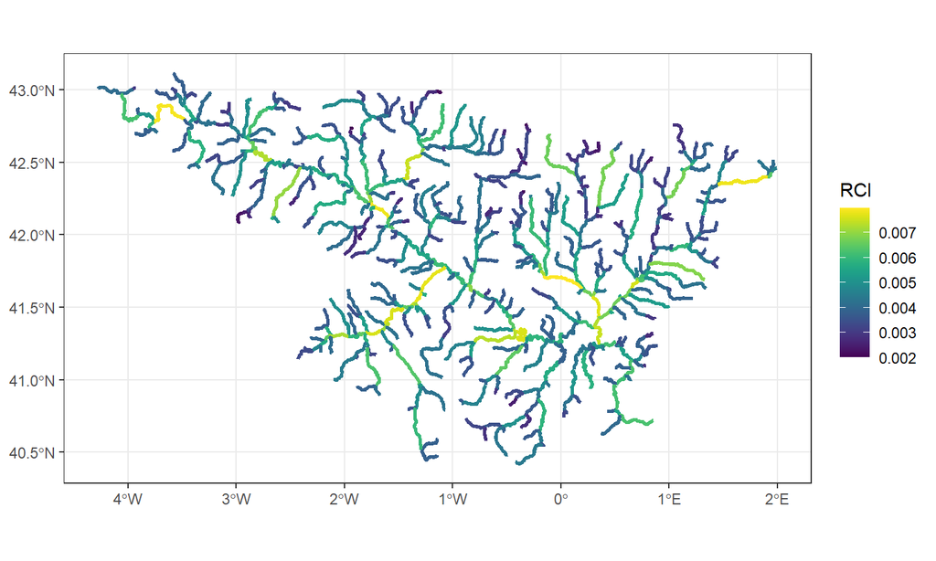

## Spatial patterns of RCI

We calculate and plot the RCI with pass_u = 0.1, pass_d = 0.8 and symmetric dispersal limitation (PD = 0.8).

```r
index <- index_list[[4]]  <- index_calculation(
    g, dir_fragmentation_type ="asymmetric",
    index_type = "reach", index_mode = "to", param = 0.8) %>%
  dplyr::mutate("def" = "PD=0.8")

plot <- river_net_simplified %>%
  left_join(index, by = "name") %>%
  ggplot() +
  geom_sf(aes(color = index), size = 1) +
  scale_color_viridis() + theme_bw() +
  labs(color = "RCI")
```

## Spatial patterns of RCI

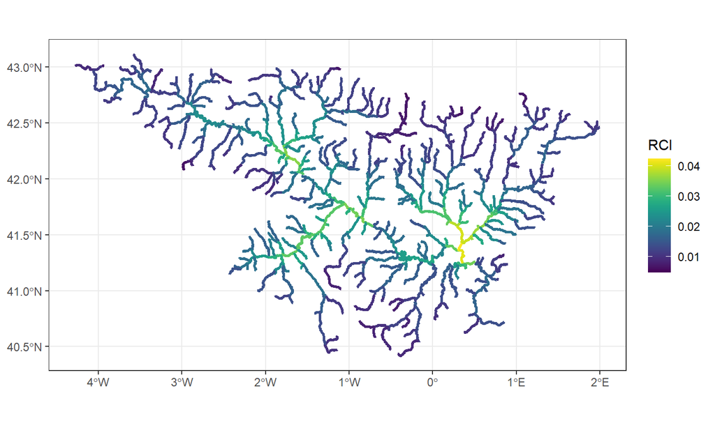

## Spatial patterns of RCI

We calculate and plot the RCI with pass_u = 0.1, pass_d = 0.8 and asymmetric dispersal limitation (PDd = 0.8, PDu = 0).

```r
index <- index_list[[5]]  <- index_calculation(
    g, dir_fragmentation_type ="asymmetric", dir_distance_type = "asymmetric",
    index_type = "reach", index_mode = "to", param_d = 0.8, param_u = 0) %>%
  dplyr::mutate("def" = "PDu=0, PDd=0.8")

plot <- river_net_simplified %>%
  left_join(index, by = "name") %>%
  ggplot() +
  geom_sf(aes(color = index), size = 1) +
  scale_color_viridis() + theme_bw() +
  labs(color = "RCI")
```

## Spatial patterns of RCI

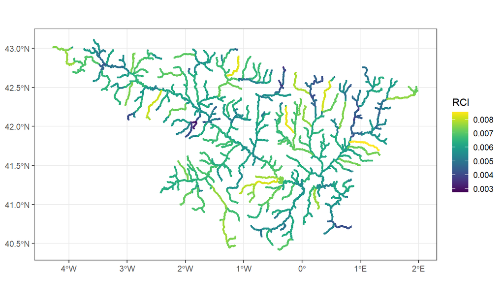

## Spatial patterns of RCI

We calculate and plot the RCI with pass_u = 0.1, pass_d = 0.8 and asymmetric dispersal limitation (PDd = 0.5, PDu = 0).

```r
index <- index_list[[6]]  <- index_calculation(
    g, dir_fragmentation_type ="asymmetric", dir_distance_type = "asymmetric",
    index_type = "reach", index_mode = "to", param_d = 0.5, param_u = 0) %>%
  dplyr::mutate("def" = "PDu=0.5, PDd=0")

plot <- river_net_simplified %>%
  left_join(index, by = "name") %>%
  ggplot() +
  geom_sf(aes(color = index), size = 1) +
  scale_color_viridis() + theme_bw() +
  labs(color = "RCI")
```

## Spatial patterns of RCI

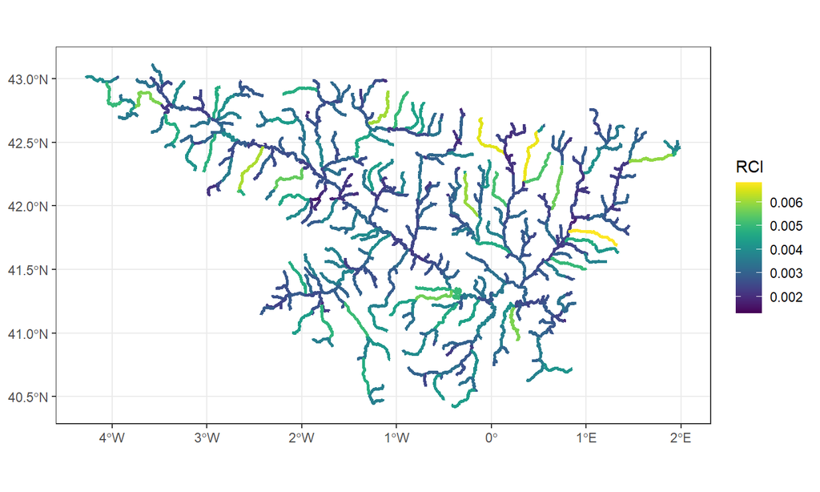

## Spatial patterns of RCI

We plot everything together to check the differences.

```r
index_all <- do.call(rbind, index_list) %>%
  group_by(def) %>%
  dplyr::mutate(rank = rank(index))

plot <- river_net_simplified %>%
  left_join(index_all, by = "name") %>%
  ggplot() + theme_minimal() +
  geom_sf(aes(color = rank), size = 1) +
  scale_color_viridis() + theme_bw() +
  labs(color = "RCI") + facet_wrap(~def) +
  theme(axis.text = element_blank(), axis.ticks = element_blank())
```

## Spatial patterns of RCI

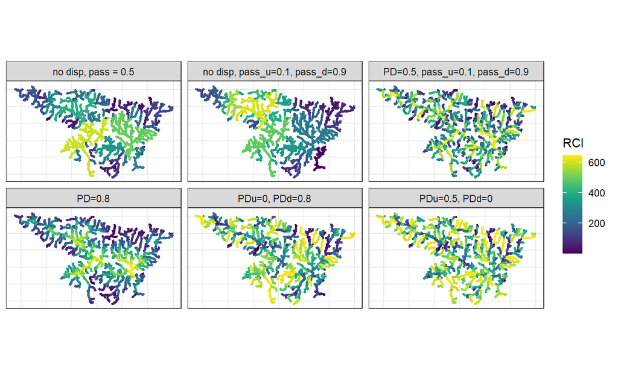

## Spatial patterns of dCCI

## Spatial patterns of dCCI

We create the object updt_pass with the updated passability values.

```r
updt_pass <- data.frame(
  "id_barrier" =  E(river_graph)$id_barrier[!is.na(E(river_graph)$id_barrier)],
  "pass_u_updated" = 1,
  "pass_d_updated" = 1)
head(updt_pass)
```

```
##   id_barrier pass_u_updated pass_d_updated
## 1         76              1              1
## 2         72              1              1
## 3          7              1              1
## 4          6              1              1
## 5         78              1              1
## 6         51              1              1
```

## Spatial patterns of dCCI

We use the function `d_index_calculation()` to calculate the \(dCCI\) for each barrier. Here, we calculate the index with no dispersal, and pass_u = pass_d = 0.5

```r
index_list <- list()
g <- river_graph

# E(g)$pass_d <- E(g)$pass_u <- ifelse(!is.na(E(g)$id_barrier),0.5,NA)
index <- index_list[[1]]  <- d_index_calculation(
    g, barriers_metadata = updt_pass,
    B_ij_flag = FALSE, ncores = 5) %>%
  dplyr::mutate("index_type" = "DCI", "disp" = "dispersal: no")

plot <- ggplot() +
  geom_sf(data = river_net_simplified, color = "gray70") +
  geom_sf(data = dams_shp %>% left_join(index),
          aes(color = d_index, size = d_index)) +
  scale_color_viridis() + theme_bw() +
  labs(color = "dCCI") + guides(size = FALSE)
```

## Spatial patterns of dCCI

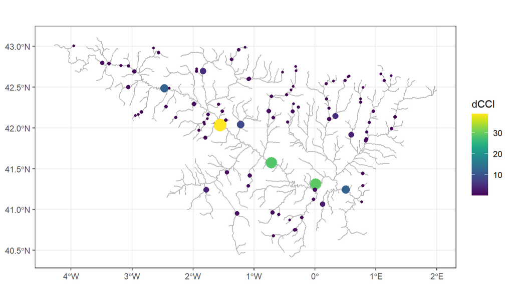

## Spatial patterns of dCCI

Now we include as weight the habitat suitabiity for high altitude organisms.

```r
g <- river_graph

# E(g)$pass_d <- E(g)$pass_u <- ifelse(!is.na(E(g)$id_barrier),0.5,NA)
index <- index_list[[2]]  <- d_index_calculation(
    g, barriers_metadata = updt_pass,
    weight = "HSI_high",  B_ij_flag = FALSE, ncores = 5) %>%
  dplyr::mutate("index_type" = "PCI high", "disp" = "dispersal: no")

plot <- ggplot() +
  geom_sf(data = river_net_simplified, color = "gray70") +
  geom_sf(data = dams_shp %>% left_join(index),
          aes(color = d_index, size = d_index)) +
  scale_color_viridis() + theme_bw() +
  labs(color = "dCCI") + guides(size = FALSE)
```

## Spatial patterns of dCCI

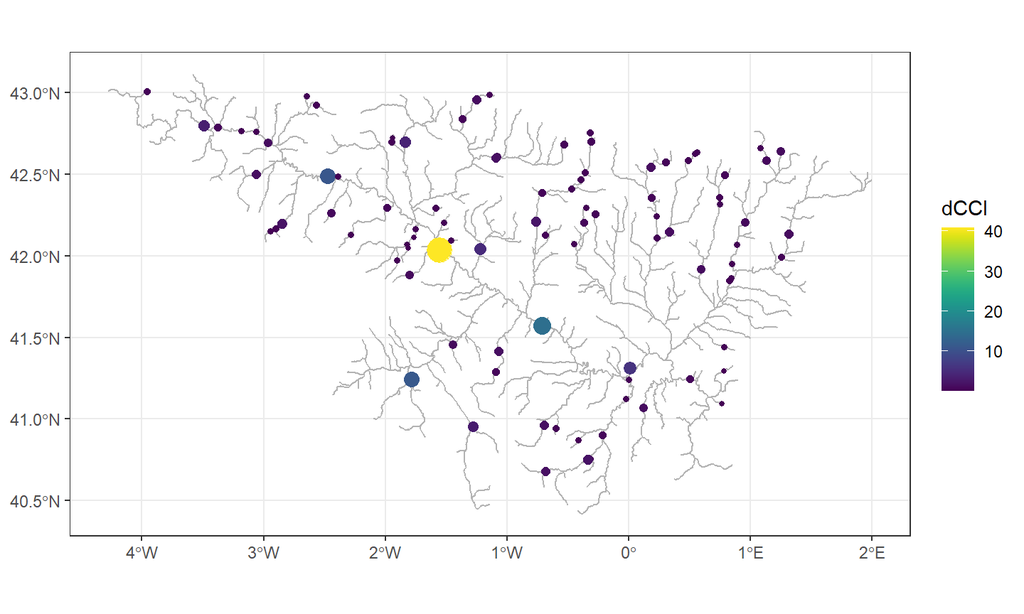

## Spatial patterns of dCCI

Now we include as weight the habitat suitabiity for low altitude organisms.

```r
g <- river_graph

# E(g)$pass_d <- E(g)$pass_u <- ifelse(!is.na(E(g)$id_barrier),0.5,NA)
index <- index_list[[3]]  <- d_index_calculation(
    g, barriers_metadata = updt_pass,
    weight = "HSI_low",  B_ij_flag = FALSE, ncores = 5) %>%
  dplyr::mutate("index_type" = "PCI low", "disp" = "dispersal: no")

plot <- ggplot() +
  geom_sf(data = river_net_simplified, color = "gray70") +
  geom_sf(data = dams_shp %>% left_join(index),
          aes(color = d_index, size = d_index)) +
  scale_color_viridis() + theme_bw() +
  labs(color = "dCCI") + guides(size = FALSE)
```

## Spatial patterns of dCCI

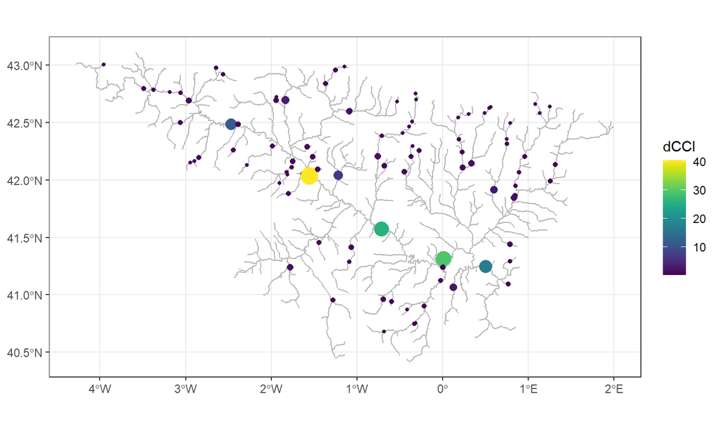

## Spatial patterns of dCCI

Now we calculate the \(dCCI\) with dispersal limitation and asymmetric dispersal.

```r
g <- river_graph

# E(g)$pass_d <- E(g)$pass_u <- ifelse(!is.na(E(g)$id_barrier),0.5,NA)
index <- index_list[[4]]  <- d_index_calculation(
    g, dir_distance_type = "asymmetric", param_d = 0.5, param_u = 0,
    barriers_metadata = updt_pass, ncores = 5) %>%
  dplyr::mutate("index_type" = "DCI", "disp" = "dispersal: yes")

plot <- ggplot() +
  geom_sf(data = river_net_simplified, color = "gray70") +
  geom_sf(data = dams_shp %>% left_join(index),
          aes(color = d_index, size = d_index)) +
  scale_color_viridis() + theme_bw() +
  labs(color = "dCCI") + guides(size = FALSE)
```

## Spatial patterns of dCCI

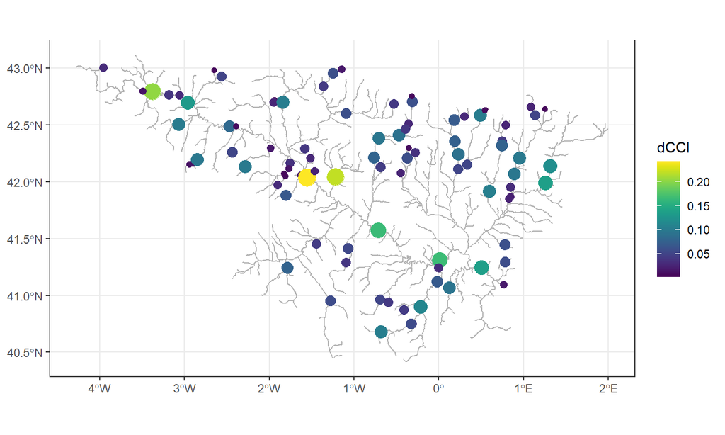

## Spatial patterns of dCCI

Now we include as weight the habitat suitabiity for high altitude organisms and asymmetric dispersal.

```r
g <- river_graph

# E(g)$pass_d <- E(g)$pass_u <- ifelse(!is.na(E(g)$id_barrier),0.5,NA)
index <- index_list[[5]]  <- d_index_calculation(
    g, dir_distance_type = "asymmetric", param_d = 0.5, param_u = 0,
    barriers_metadata = updt_pass, weight = "HSI_high",  ncores = 5) %>%
  dplyr::mutate("index_type" = "PCI high", "disp" = "dispersal: yes")

plot <- ggplot() +
  geom_sf(data = river_net_simplified, color = "gray70") +
  geom_sf(data = dams_shp %>% left_join(index),
          aes(color = d_index, size = d_index)) +
  scale_color_viridis() + theme_bw() +
  labs(color = "dCCI") + guides(size = FALSE)
```

## Spatial patterns of dCCI

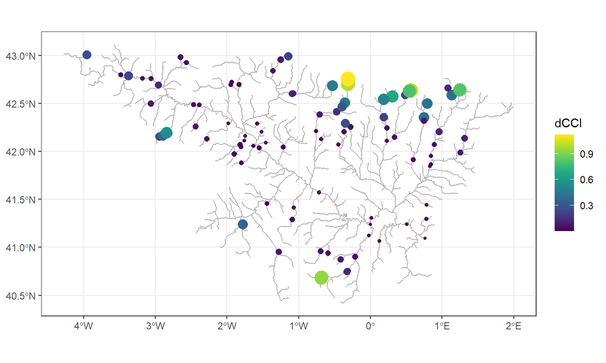

## Spatial patterns of dCCI

Now we include as weight the habitat suitabiity for low altitude organisms and asymmetric dispersal.

```r
g <- river_graph

# E(g)$pass_d <- E(g)$pass_u <- ifelse(!is.na(E(g)$id_barrier),0.5,NA)
index <- index_list[[6]]  <- d_index_calculation(
   g, dir_distance_type = "asymmetric", param_d = 0.5, param_u = 0,
   barriers_metadata = updt_pass, weight = "HSI_low", ncores = 5) %>%
  dplyr::mutate("index_type" = "PCI low", "disp" = "dispersal: yes")

plot <- ggplot() +
  geom_sf(data = river_net_simplified, color = "gray70") +
  geom_sf(data = dams_shp %>% left_join(index),
          aes(color = d_index, size = d_index)) +
  scale_color_viridis() + theme_bw() +
  labs(color = "dCCI") + guides(size = FALSE)
```

## Spatial patterns of dCCI

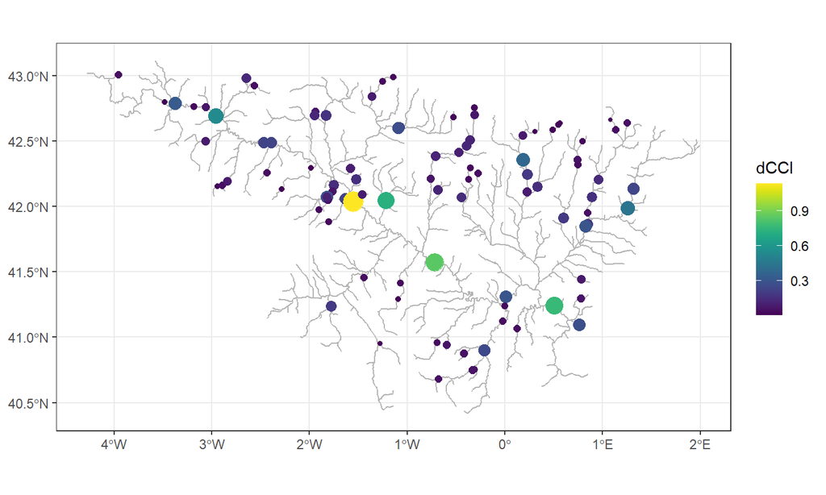

## Spatial patterns of dCCI

We plot everything together to check the differences.

```r
index_all <- do.call(rbind, index_list) %>%
  group_by(index_type, disp) %>%
  dplyr::mutate(rank = rank(desc(index))) %>%
  ungroup()

plot <- ggplot() + theme_minimal() +
  geom_sf(data = river_net_simplified, color = "gray70") +
  geom_sf(data = dams_shp %>%  right_join(index_all, by = "id_barrier"),
          aes(color = rank, size = 1/rank), alpha = 0.5) +
  scale_color_viridis(name = "Rank", direction = -1) + theme_bw() +
  labs(color = "RCI") + facet_grid(disp ~ index_type) + guides(size = FALSE) +
  theme(axis.text = element_blank(), axis.ticks = element_blank())
```

## Spatial patterns of dCCI

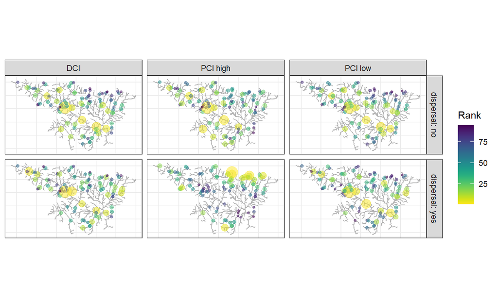

## Spatial patterns of dCCI

```r
corr_mat <- index_all %>%
  dplyr::mutate(index_type_disp = paste(index_type, disp)) %>%
  dplyr::select(id_barrier, index, index_type_disp) %>%
  pivot_wider(names_from = index_type_disp, values_from = index) %>%
  dplyr::select(-id_barrier) %>%
  cor(method = "spearman")
```

## Spatial patterns of dCCI

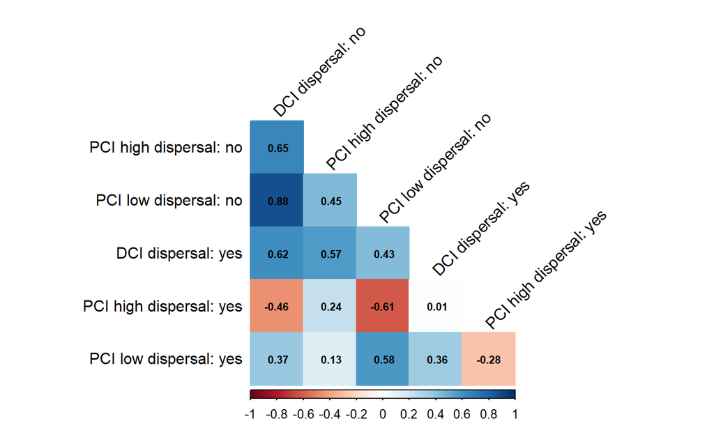